# The Economics Behind Happiness

Aaron Polar

December 14, 2021

Preface: The packages used in this data exploration project are ggplot2 and dplyr.

### Introduction

For this project, I needed to manipulate the data in order to clean up the data set. I compiled the data into one data frame and remove irrelevant variables:  
-Standard error of ladder score  
-upperwhisker  
-lowerwhisker  
-Ladder score in Dystopia  
-Explained by: Log GDP per capita  
-Explained by: Social support  
-Explained by: Healthy life expectancy  
-Explained by: Freedom to make life choices  
-Explained by: Generosity  
-Explained by: Perceptions of corruption  
-Dystopia + residual

```
The variables used in this data set are listed as follows:
Happiness: A ladder with steps numbered from 0 to 10 at the top. The top of the ladder (A score of 10) represents the best possible life for you and the bottom of the ladder represents the worst possible life for you. Surveyors were asked “On which step of the ladder would you say you personally feel you stand at this time?”

GDP Per Capita: Gross Domestic Product per individual in a country

Social support: Surveyors were asked “Do you have someone to count on in times of trouble?”; Binary response: 0=No, 1=Yes

Healthy Life expectancy: Healthy life expectancy at birth

Freedom to make choices: Surveyors were asked “Are you satisfied or dissatisfied with your freedom to choose what you do with your life?”

Generosity: Surveyors were asked “Have you donated money to a charity in the past month?”

Perceptions of Corruption:  “Is corruption widespread throughout the government or not” and “Is corruption widespread
within businesses or not?”; Average of a Binary response: 0=No, 1=Yes
```

### Part 1

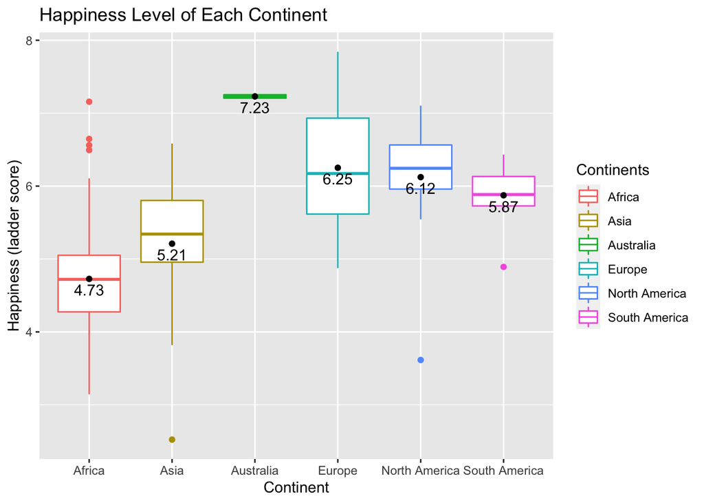

[output not shown]

```r
means <- aggregate(Ladder.score ~  Regional.indicator, working_df, mean)
ggplot(working_df,
              aes(x=Regional.indicator,
                  y=Ladder.score,
                  color=Regional.indicator)) +
  geom_boxplot()+
  stat_summary(fun = mean, geom = "point", col = "black") +
  stat_summary(fun = mean, geom = "text", col = "black",
               vjust = 1.5, aes(label = paste(round(..y.., digits = 2)))) +
  xlab("Continent") +
  ylab("Happiness (ladder score)")+
  ggtitle("Happiness Level of Each Continent") +
  guides(col=guide_legend("Continents"))
```

### Are those who are free to make life decisions happier?

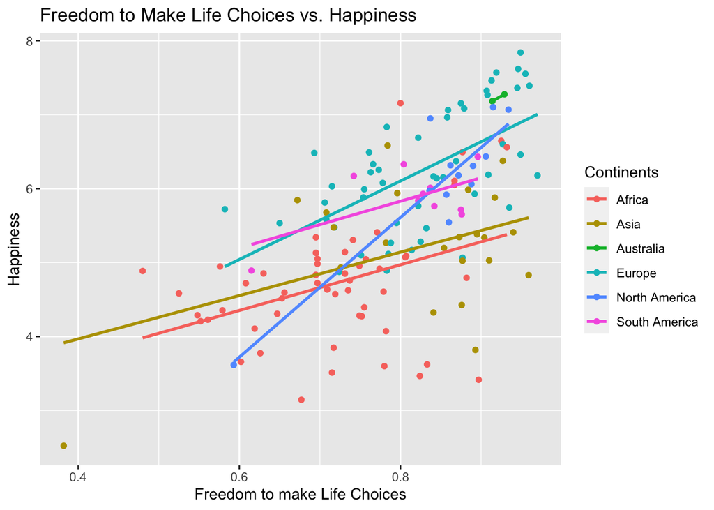

[output not shown]

```r
colors<- c("Asia"= "red", "Europe" = "blue", "Africa"="green", "Australia"="orange", "North America"= "brown", "South America"= "yellow")

ggplot(working_df,
       aes(x=Freedom.to.make.life.choices,
           y=Ladder.score,
           color=Regional.indicator)) +
  geom_point() +
  xlab("Freedom to make Life Choices") +
  ylab("Happiness") +
  ggtitle("Freedom to Make Life Choices vs. Happiness") +
  guides(col=guide_legend("Continents")) +
  geom_smooth(method = "lm", se = FALSE)
```

### Are those who are happier more generous?

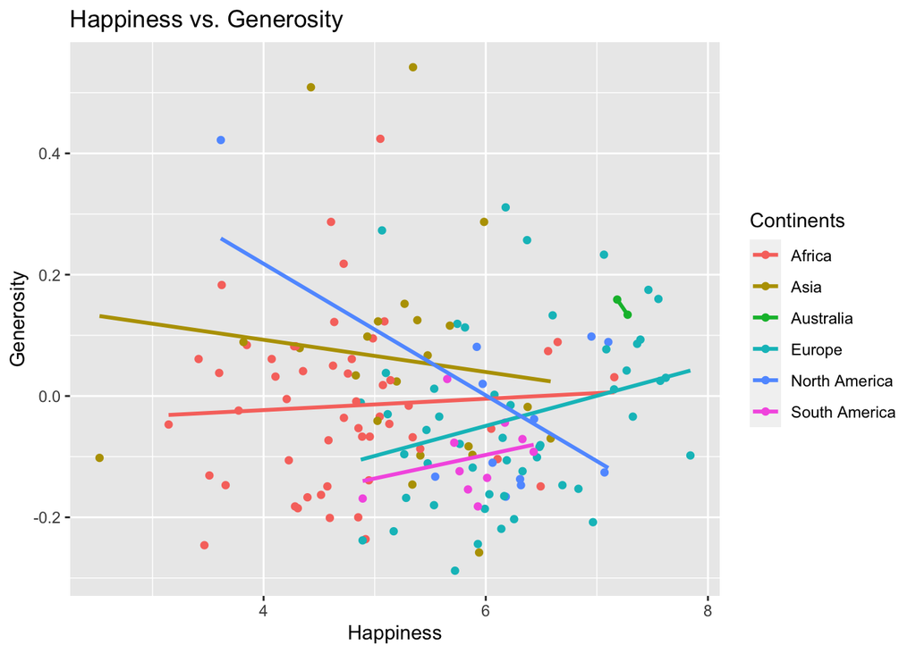

[output not shown]

```r
colors<- c("Asia"= "red", "Europe" = "blue", "Africa"="green", "Australia"="orange", "North America"= "brown", "South America"= "yellow")

ggplot(working_df, aes(x=Ladder.score, y=Generosity, color = Regional.indicator)) +
  geom_point() +
  xlab("Happiness") +
  ylab("Generosity") +
  ggtitle("Happiness vs. Generosity") +
  guides(col=guide_legend("Continents")) +
  geom_smooth(method = "lm", se = FALSE)
```

### What is the best indicator to living a happy life?

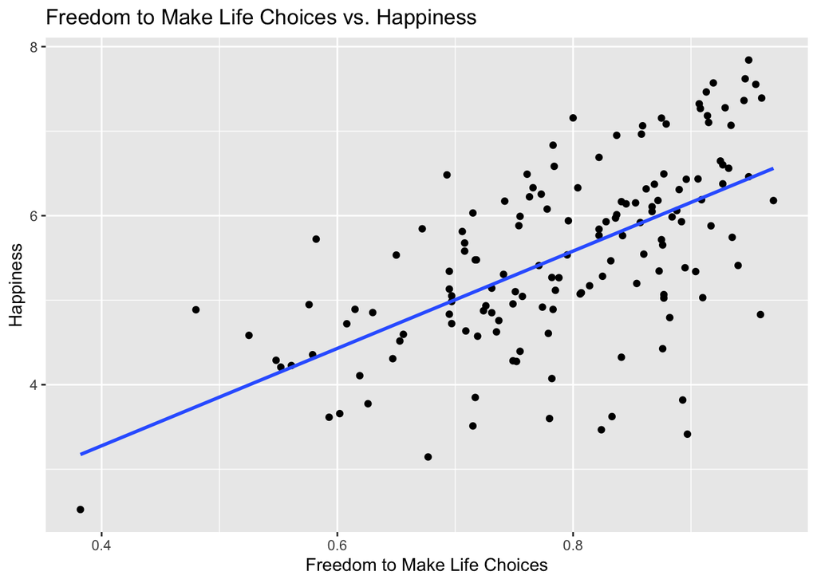

```r
ggplot(working_df, aes(x=Freedom.to.make.life.choices, y=Ladder.score)) +
  geom_point() +
  xlab("Freedom to Make Life Choices") +
  ylab("Happiness") +
  ggtitle("Freedom to Make Life Choices vs. Happiness")+
  geom_smooth(method = "lm", se = FALSE)
```

```r
regression_hf<- lm(Freedom.to.make.life.choices ~ Ladder.score,
               data = working_df)
summary(regression_hf)
```

```
##
## Call:
## lm(formula = Freedom.to.make.life.choices ~ Ladder.score, data = working_df)
##
## Residuals:
##      Min       1Q   Median       3Q      Max
## -0.27017 -0.06491  0.01070  0.04862  0.24123
##
## Coefficients:
##              Estimate Std. Error t value Pr(>|t|)
## (Intercept)  0.436740   0.038952  11.212   <2e-16 ***
## Ladder.score 0.064137   0.006912   9.279   <2e-16 ***
## ---
## Signif. codes:  0 '***' 0.001 '**' 0.01 '*' 0.05 '.' 0.1 ' ' 1
##
## Residual standard error: 0.09031 on 147 degrees of freedom
## Multiple R-squared:  0.3694, Adjusted R-squared:  0.3651
## F-statistic:  86.1 on 1 and 147 DF,  p-value: < 2.2e-16
```

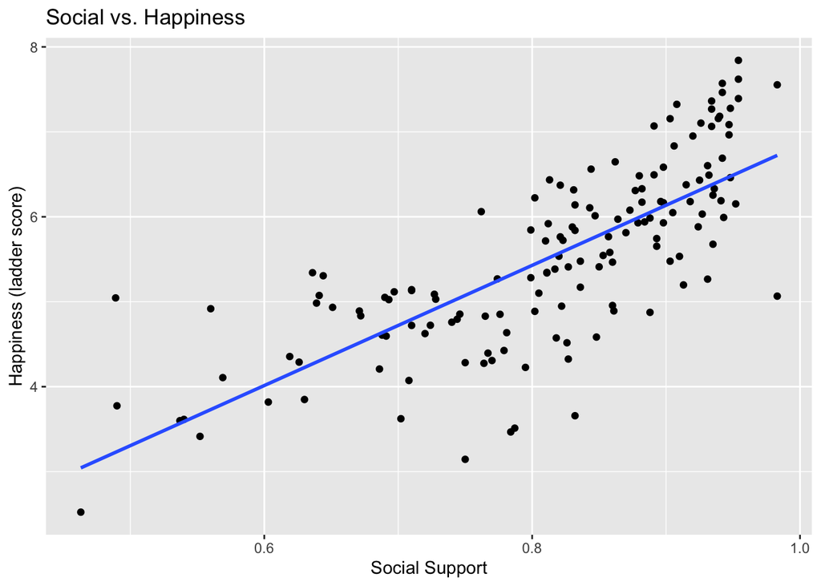

```r
scatter_social_happy<- ggplot(working_df, aes(x=Social.support, y=Ladder.score)) +
  geom_point() +
  xlab("Social Support") +
  ylab("Happiness (ladder score)") +
  ggtitle("Social vs. Happiness")+
  geom_smooth(method = "lm", se = FALSE)
scatter_social_happy
```

```r
regression_hs<- lm(Ladder.score ~ Social.support,
               data = working_df)
summary(regression_hs)
```

```
##
## Call:
## lm(formula = Ladder.score ~ Social.support, data = working_df)
##
## Residuals:
##      Min       1Q   Median       3Q      Max
## -1.99692 -0.37127  0.02443  0.46213  1.81681
##
## Coefficients:
##                Estimate Std. Error t value Pr(>|t|)
## (Intercept)     -0.2315     0.4146  -0.558    0.577
## Social.support   7.0750     0.5039  14.042   <2e-16 ***
## ---
## Signif. codes:  0 '***' 0.001 '**' 0.01 '*' 0.05 '.' 0.1 ' ' 1
##
## Residual standard error: 0.7042 on 147 degrees of freedom
## Multiple R-squared:  0.5729, Adjusted R-squared:   0.57
## F-statistic: 197.2 on 1 and 147 DF,  p-value: < 2.2e-16
```

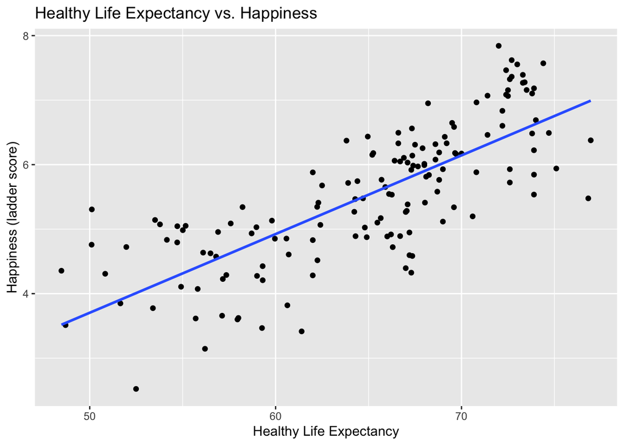

```r
scatter_healthy_happy<- ggplot(working_df, aes(x=Healthy.life.expectancy, y=Ladder.score)) +
  geom_point() +
  xlab("Healthy Life Expectancy") +
  ylab("Happiness (ladder score)") +
  ggtitle("Healthy Life Expectancy vs. Happiness")+
  geom_smooth(method = "lm", se = FALSE)
scatter_healthy_happy
```

```r
regression_hh<- lm(Ladder.score ~ Healthy.life.expectancy,
               data = working_df)
summary(regression_hh)
```

```
##
## Call:
## lm(formula = Ladder.score ~ Healthy.life.expectancy, data = working_df)
##
## Residuals:
##      Min       1Q   Median       3Q      Max
## -1.67956 -0.49054  0.09232  0.56360  1.58818
##
## Coefficients:
##                          Estimate Std. Error t value Pr(>|t|)
## (Intercept)             -2.395426   0.548061  -4.371 2.33e-05 ***
## Healthy.life.expectancy  0.121987   0.008388  14.544  < 2e-16 ***
## ---
## Signif. codes:  0 '***' 0.001 '**' 0.01 '*' 0.05 '.' 0.1 ' ' 1
##
## Residual standard error: 0.69 on 147 degrees of freedom
## Multiple R-squared:   0.59,  Adjusted R-squared:  0.5872
## F-statistic: 211.5 on 1 and 147 DF,  p-value: < 2.2e-16
```

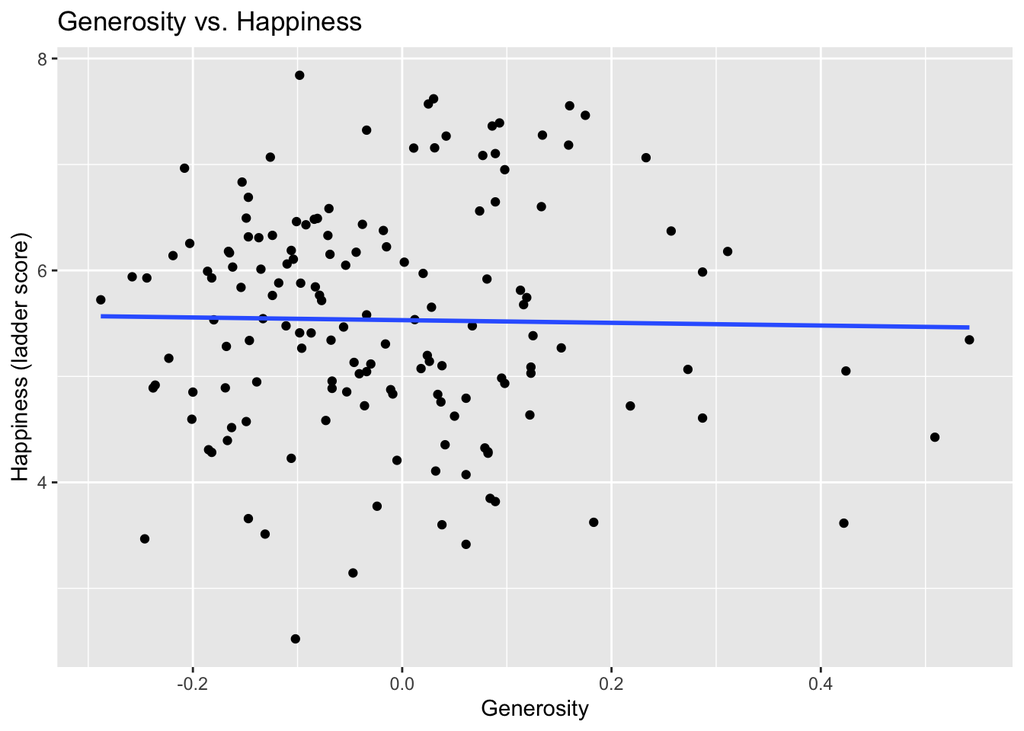

```r
scatter_generosity_happy<- ggplot(working_df, aes(x=Generosity, y=Ladder.score)) +
  geom_point() +
  xlab("Generosity") +
  ylab("Happiness (ladder score)") +
  ggtitle("Generosity vs. Happiness")+
  geom_smooth(method = "lm", se = FALSE)
scatter_generosity_happy
```

```r
regression_hg<- lm(Ladder.score ~ Generosity,
               data = working_df)
summary(regression_hg)
```

```
##
## Call:
## lm(formula = Ladder.score ~ Generosity, data = working_df)
##
## Residuals:
##      Min       1Q   Median       3Q      Max
## -3.02086 -0.69660 -0.01976  0.69832  2.29865
##
## Coefficients:
##             Estimate Std. Error t value Pr(>|t|)
## (Intercept)  5.53092    0.08871  62.347   <2e-16 ***
## Generosity  -0.12688    0.58784  -0.216    0.829
## ---
## Signif. codes:  0 '***' 0.001 '**' 0.01 '*' 0.05 '.' 0.1 ' ' 1
##
## Residual standard error: 1.077 on 147 degrees of freedom
## Multiple R-squared:  0.0003168,  Adjusted R-squared:  -0.006484
## F-statistic: 0.04659 on 1 and 147 DF,  p-value: 0.8294
```

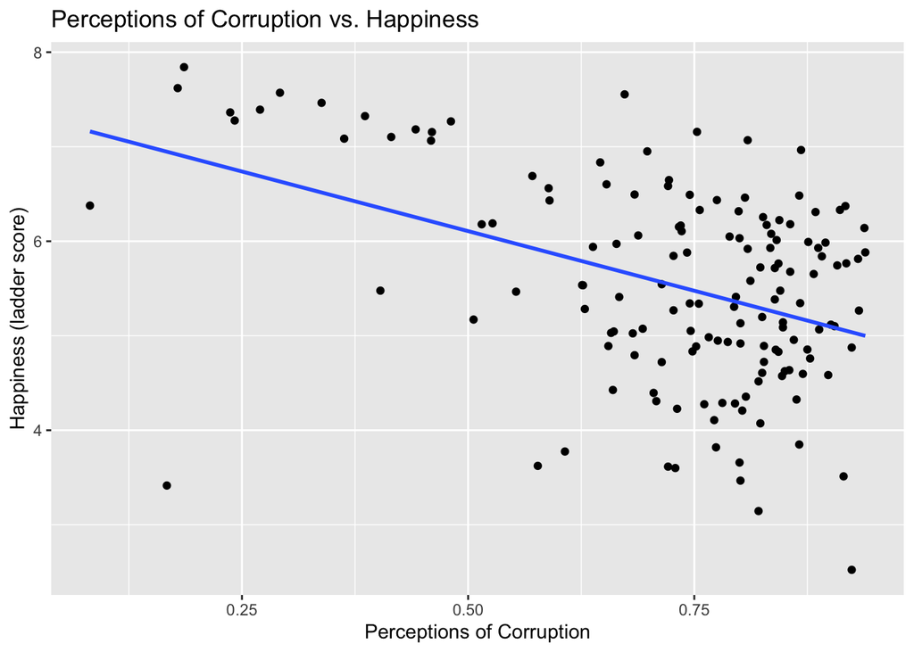

```r
scatter_perception_happy<- ggplot(working_df, aes(x=Perceptions.of.corruption, y=Ladder.score)) +
  geom_point() +
  xlab("Perceptions of Corruption") +
  ylab("Happiness (ladder score)") +
  ggtitle("Perceptions of Corruption vs. Happiness")+
  geom_smooth(method = "lm", se = FALSE)
scatter_perception_happy
```

```r
regression_hp<- lm(Ladder.score ~ Perceptions.of.corruption,
               data = working_df)
summary(regression_hp)
```

```
##
## Call:
## lm(formula = Ladder.score ~ Perceptions.of.corruption, data = working_df)
##
## Residuals:
##     Min      1Q  Median      3Q     Max
## -3.5321 -0.5986  0.1101  0.7938  1.8838
##
## Coefficients:
##                           Estimate Std. Error t value Pr(>|t|)
## (Intercept)                 7.3685     0.3358   21.95  < 2e-16 ***
## Perceptions.of.corruption  -2.5235     0.4482   -5.63 8.88e-08 ***
## ---
## Signif. codes:  0 '***' 0.001 '**' 0.01 '*' 0.05 '.' 0.1 ' ' 1
##
## Residual standard error: 0.9774 on 147 degrees of freedom
## Multiple R-squared:  0.1774, Adjusted R-squared:  0.1718
## F-statistic: 31.69 on 1 and 147 DF,  p-value: 8.881e-08
```

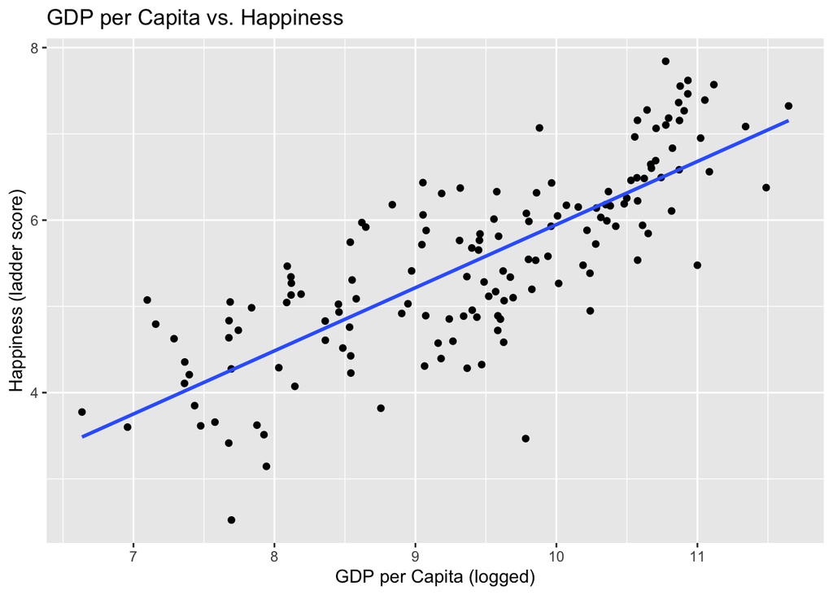

```r
scatter_gdp_happy<- ggplot(working_df, aes(x=Logged.GDP.per.capita, y=Ladder.score)) +
  geom_point() +
  xlab("GDP per Capita (logged)") +
  ylab("Happiness (ladder score)") +
  ggtitle("GDP per Capita vs. Happiness")+
  geom_smooth(method = "lm", se = FALSE)
scatter_gdp_happy
```

```r
regression_hl<- lm(Ladder.score ~ Logged.GDP.per.capita,
               data = working_df)
summary(regression_hl)
```

```
##
## Call:
## lm(formula = Ladder.score ~ Logged.GDP.per.capita, data = working_df)
##
## Residuals:
##      Min       1Q   Median       3Q      Max
## -2.32190 -0.46198  0.08206  0.50740  1.32618
##
## Coefficients:
##                       Estimate Std. Error t value Pr(>|t|)
## (Intercept)            -1.3719     0.4456  -3.079  0.00248 **
## Logged.GDP.per.capita   0.7320     0.0469  15.610  < 2e-16 ***
## ---
## Signif. codes:  0 '***' 0.001 '**' 0.01 '*' 0.05 '.' 0.1 ' ' 1
##
## Residual standard error: 0.661 on 147 degrees of freedom
## Multiple R-squared:  0.6237, Adjusted R-squared:  0.6212
## F-statistic: 243.7 on 1 and 147 DF,  p-value: < 2.2e-16
```

```
Based on the explanatory variables given in the data set, the best indicator for happiness is GDP per capita with an R²=0.6237.
```

### Are the explanitory variables significant?

```r
regression <- lm(Ladder.score ~ Logged.GDP.per.capita + Social.support + Healthy.life.expectancy + Freedom.to.make.life.choices + Generosity + Perceptions.of.corruption, data=working_df)
summary(regression)
```

```
##
## Call:
## lm(formula = Ladder.score ~ Logged.GDP.per.capita + Social.support +
##     Healthy.life.expectancy + Freedom.to.make.life.choices +
##     Generosity + Perceptions.of.corruption, data = working_df)
##
## Residuals:
##      Min       1Q   Median       3Q      Max
## -1.85049 -0.30026  0.05735  0.33368  1.04878
##
## Coefficients:
##                              Estimate Std. Error t value Pr(>|t|)
## (Intercept)                  -2.23722    0.63049  -3.548 0.000526 ***
## Logged.GDP.per.capita         0.27953    0.08684   3.219 0.001595 **
## Social.support                2.47621    0.66822   3.706 0.000301 ***
## Healthy.life.expectancy       0.03031    0.01333   2.274 0.024494 *
## Freedom.to.make.life.choices  2.01046    0.49480   4.063 7.98e-05 ***
## Generosity                    0.36438    0.32121   1.134 0.258541
## Perceptions.of.corruption    -0.60509    0.29051  -2.083 0.039058 *
## ---
## Signif. codes:  0 '***' 0.001 '**' 0.01 '*' 0.05 '.' 0.1 ' ' 1
##
## Residual standard error: 0.5417 on 142 degrees of freedom
## Multiple R-squared:  0.7558, Adjusted R-squared:  0.7455
## F-statistic: 73.27 on 6 and 142 DF,  p-value: < 2.2e-16
```

[output not shown]

### Just for fun, how would I rank on the Happiness scale?

#### In a new country called Aaronville with Logged.GDP.per.capita of 6.9078 (ln($1000)), Social.support of 1, Healthy.life.expectancy= 68.200 (taken from United States data), Generosity= 0, Perceptions.of.corruption=0.5)

```r
aaronville<- data.frame(Logged.GDP.per.capita=6.9078, Social.support = 1, Healthy.life.expectancy= 68.200, Freedom.to.make.life.choices=1, Generosity= 0, Perceptions.of.corruption=0.5)
predict(regression, newdata=aaronville)
```

```
##        1
## 5.945265
```

[output not shown]

#### Multiple Linear Regression Model

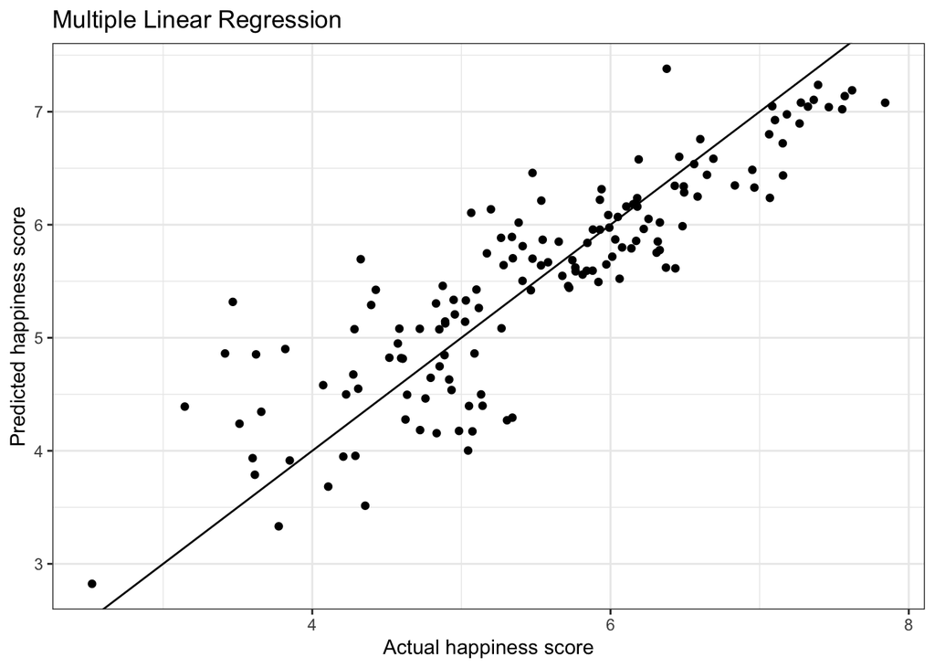

```r
y_pred_lm = predict(regression, newdata = working_df)

Pred_Actual_lm <- as.data.frame(cbind(Prediction = y_pred_lm, Actual = working_df$Ladder.score))

gg.lm <- ggplot(Pred_Actual_lm, aes(Actual, Prediction )) +
  geom_point() + theme_bw() + geom_abline() +
  labs(title = "Multiple Linear Regression", x = "Actual happiness score",
       y = "Predicted happiness score")
gg.lm
```

### Conclusion

Based on the explanatory variables given in the data set, the best indicator for happiness is GDP per capita with an R²=0.6237. However, 0.6237 is still quite far from a perfectly correlated R² value of 1 this makes me wonder if there are there better happiness indicators to explore such as job security, parks per square mile, number of pets per household.  
Some problems I faced during this project the significance levels of the explanatory variables. Additionally, I think some regions had more countries than others which skewed the box plot and regression due to a low sample size. Lastly, I could have split up the continent region indicator into more specific regions such as Western/Eastern Europe, North/Central/South America, Carribean, Sub Saharan/Central/South Africa, Middle East, East/South/Southeast Asia, Pacific Islands, and Oceania. By doing this, I’ll be able to accurately determine the variance in different factors instead of blindly categorizing culturally and economically different countries together based on their location.  
In a future project, I’d like to explore more factors that determine happiness levels in certain regions. Explanatory variables such as GDP per capita, annual income per household, government expenditure on education, government expenditure on healthcare, and import to export ratio in order to fully answer the age old question *“Does money buy happiness?”*